# Milestone Report for NLP Capstone Project

Data Science Specialization on Coursera

Vadim K.

22 August 2017

## Synopsis

The purpose of this document is to provide a milestone report on developing an interactive text prediction web app.  
This developement is a part of the capstone project that wraps up Coursera Data Science specialization offered by Johns Hopkins University (Baltimore, Maryland).

This application will predict the next word a user most likely will type based on the words he/she already typed.  
The server part of application will run a word prediction algorithm that will be finalized later in the project. This algorithm is based on N-gram language model built from [HC Corpora](https://web-beta.archive.org/web/20160930083655/http://www.corpora.heliohost.org/aboutcorpus.html) (a set of files with millions lines of text in different languages collected from publicly available sources by a web crawler).

In the present document I will give a brief overview of the first steps of the project that were already achieved such as downloading, cleaning and exploring the data. I will also share couple of issues I faced and some interesting findings in the data.  
In conclusion you’ll find some info about my plans for creating the prediction algorithm and the expected constraints.

## Data Processing

The R packages used during analysis are

```
library(stringr) # to count words
library(stringi) # to count max characters (seems faster than stringr)
library(dplyr) # to rename columns of summary table
library(readtext) # to read sample file into a Corpus
library(quanteda) # for all the text mining
library(data.table) # to hold the frequency tables
library(ggplot2) # visualization
```

#### *Loading Data*

The data was obtained from the archive available under following [link](https://d396qusza40orc.cloudfront.net/dsscapstone/dataset/Coursera-SwiftKey.zip).  
It contains texts from 3 types of sources (blogs, news, Twitter) in 4 different locales (en_US, de_DE, ru_RU and fi_FI).  
Files in English were taken for this project (i.e. `"en_US.blogs.txt"; "en_US.news.txt"; "en_US.twitter.txt"`).

There was an issue with loading News file: it containes ASCII `Substitute` character on line 77259, this character (decimal 26 or 0x1A) corresponds to Ctrl+Z in Windows so the function `readLines` truncates the file at it and imports only 77259 lines.  
Solution is to launch `readLines` in binary mode (credits to [this Q on StackOverflow](https://stackoverflow.com/questions/15874619/reading-in-a-text-file-with-a-sub-1a-control-z-character-in-r-on-windows))

#### *Summary statistics*

Here is some summary statistics for the chosen files:

|  | File size | Total lines | Max. characters per line | Total words | Av. characters per word |
| --- | --- | --- | --- | --- | --- |
| en_US.blogs.txt | 248.5 Mb | 899288 | 40833 | 37874365 | 4.3 |
| en_US.news.txt | 249.6 Mb | 1010242 | 11384 | 34613673 | 4.6 |
| en_US.twitter.txt | 301.4 Mb | 2360148 | 140 | 30556137 | 4.1 |

#### *Sampling & Cleaning the Data*

As the files are pretty big for the further analysis samples of 100k lines were taken from each of them.

I also had to do another cleaning for the sample files, as after the first round of exploratory analysis some strange word pairs were discovered among the most popular ones (e.g. `"u 009f"`).  
After tracing back the issue many lines with non-ASCII characters were found

they looked like this in R (being read in binary mode)  
`"Girls night with and ! \xf0\u009f\u0092\u009c"`

and like this in the original txt file  
`Girls night with and ! ðŸ’œ`  
*Example from line #1054179 of Twitter file*

## Exploring the Data

For exploring the data I experimented with 3 different packages (`tm`, `tidytext` and `quanteda`).  
Personally I found ‘quanteda’ the most convenient for this project, so all the further text mining is done with it.

Also two different approaches were studied of taking the 3 files separately or combining them together. The decision was to combine.

So the following steps were done on text mining stage:

- The Corpus has been read with `readtext`
- Split into sentences (I found it more logical for further tokenization to treat each sentence separately not just each line) –> so we got **526 022 sentences**
- Sentences then were split by words (1-gram ‘tokens’ object) and following transformation done:
  - numbers, punctuation and different symbols removed
  - all words to lower case
  - English stop words removed *(For the sake of exploring and building word clouds. Won’t do this for prediction algorithm)*
  - Stemming applied *(btw I find quanteda stemming being the most efficient one)*
- 3 more ‘tokens’ objects were created (holding 2-, 3- and 4-grams respectively)
- Document-feature matrices created from ‘tokens’ objects, holding
  - **112 600 unique unigrams**
  - **2 387 021 unique bigrams**
  - **3 596 041 unique trigrams**
  - **3 295 301 unique four-grams**
- Data.tables were created to hold the frequences of n-grams and be used for further plotting

And below you can check-out the visualization of most popular n-grams in the studied dataset:

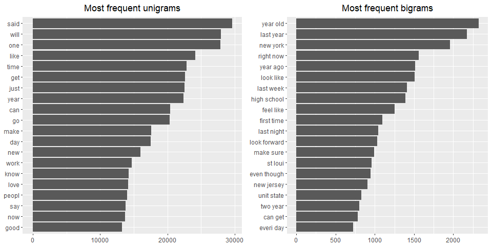

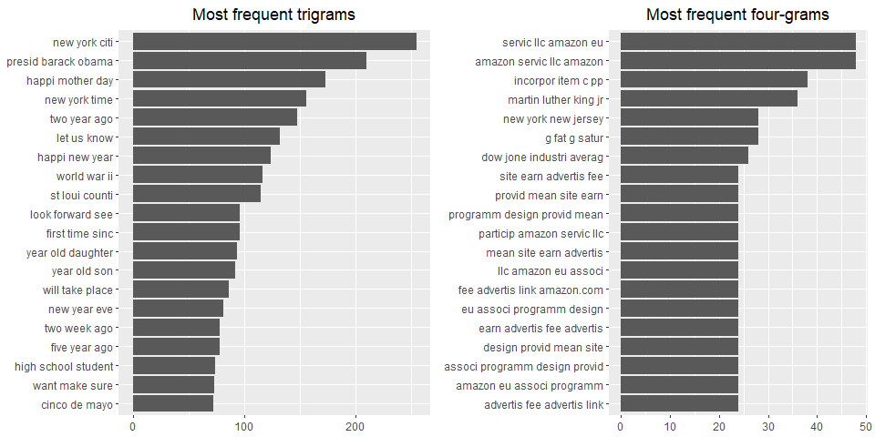

And here is another representation of unigrams and bigrams frequencies - by Word Clouds:

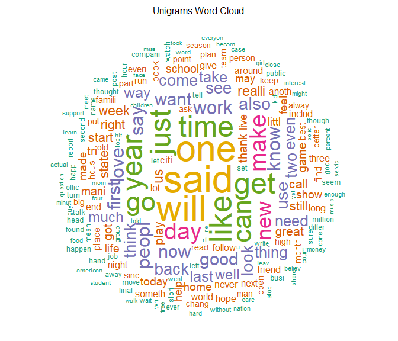

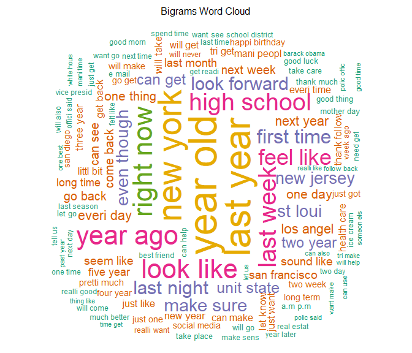

#### *Couple of interesting findings in text*

Being not from US or Mexico I was not familiar with the term ‘Cinco de Mayo’. And finding it among top 20 popular trigrams lead me to a very interesting reading on Wikipedia :)

Another one was observing similar mentionings of Amazon among popular four-grams. Tracing back to original sentences showed that there are many intances of almost the same text mentioning blogs on wordpress with random-generated-looking names.  
See examples below:

*“JBFUA Blog (jbfuablog.wordpress.com) is a participant in the Amazon Services LLC and Amazon EU Associates Programmes designed to provide a means for sites to earn advertising fees by advertising and linking to amazon.com, amazon.ca, amazon.co.uk, amazon.de, amazon.fr, amazon.it and amazon.es.”*

*“XVCYL Blog (xvcylblog.wordpress.com) is a participant in the Amazon Services LLC and Amazon EU Associates Programmes designed to provide a means for sites to earn advertising fees by advertising and linking to amazon.com, amazon.ca, amazon.co.uk, amazon.de, amazon.fr, amazon.it and amazon.es.”*

I visited couple of them - all empty, seem machine generated and differ just by title, which is still always related to selling electonics.

## Plans for Prediction Algorithm

сам алгоритм построим на n-gram language model будем использовать 1-4-граммы и smooting (поэкспериментируем с Good-Turing and Katz’s back-of) ограничения:

- размеры итоговых таблиц (будем использовать data.table, как советуют fellow data scientists on course forum),
- оперативка на Shiny Server (1 RAM), для экспериментов может сделаем вирт.машину с подобными параметрами